# R markdown main workfile

# 1 Basic stuff and data operations

## 1.1 Useful links and resources

[!!! The most useful book for R markdown - “R Markdown: The Definitive Guide”](https://bookdown.org/yihui/rmarkdown/) [Ebook “R for Graduate Students”](https://bookdown.org/yih_huynh/Guide-to-R-Book/)  
[Ebook “R for Data Science”](https://r4ds.had.co.nz/)  
[Ebook “Statistical Inference via Data Science: A ModernDive into R and Tidyverse”](https://moderndive.com/)  
[Gradient generator](https://colordesigner.io/gradient-generator)  
[ggthemes](https://yutannihilation.github.io/allYourFigureAreBelongToUs/ggthemes/)  
[R studio cheatsheets](https://www.rstudio.com/resources/cheatsheets/)  
[Introduction to ggplot2](http://r-statistics.co/Complete-Ggplot2-Tutorial-Part1-With-R-Code.html)  
[Themes for Bootstrap](https://bootswatch.com/3/)

## 1.2 Versions and plugins

To update R version: go to R GUI (old), run 1) install.packages(“installr”); library(installr); choose installr option on the tab next to the option “Help”, then update… voila!

## 1.3 Packages installation and loading:

```r
getRversion()

install.packages(c("afex", "tidyverse", "emmeans", "writexl",
    "readxl", "ggthemes", "ggplot2", "extrafont", "reshape",
    "reshape2", "gcookbook", "readr", "swirl", "ggpubr", "lubridate",
    "rmarkdown", "formatR", "knitr", "magrittr", "glue", "viridis",
    "ggsci", "gcookbook"))

install.packages("plotly")
```

```r
library(afex)
library(emmeans)
library(tidyverse)
library(writexl)
library(readxl)
library(ggthemes)
library(extrafont)
library(reshape)
library(reshape2)
library(gcookbook)
library(readr)
library(swirl)
library(ggpubr)
library(ggthemes)
library(lubridate)
library(rmarkdown)
library(formatR)
library(knitr)
library(magrittr)
library(glue)
library(viridis)
library(ggsci)
```

```r
library(gcookbook)
library(plotly)
font_import()  # for extrafont package
loadfonts(device = "win")  # loading fonts from extrafont
```

## 1.4 Functionality

- Ctrl + shift + R : creates headers for your R script
- Alt + shift + K : displays all programmed keyboard shortcuts for R
- Ctrl + shift + M : write “%>%” (tidyverse pipe)

## 1.5 Basic commands

- Save as .csv: `write_csv(name, "filename.csv")`
- Import data from .txt file: `read.csv("filename.txt", sep="\t", header=FALSE)`
- read.csv(“filename.csv”) # import data from csv file
- ironmansuits <- read.csv(“C:/Users/evgen/Desktop/R_work_folder/Iron_Man_Suits.csv”, stringsAsFactors=TRUE)
- mutate() # creates new columns or modifies current variables in the dataset
- diamonds %>% mutate(depth_times_price = depth * price)
- diamonds %>% mutate(depth_times_price = depth * price, is_cut_ideal = cut == “Ideal”)
- analog of f-string in R: library(glue): `glue("Variable {varname}")`
- Export graph as .tiff: `ggsave("test.tiff", units="in", width=8, height=6, dpi=300, compression = 'lzw')`

**Operators AND (&), OR (|)**

- diamonds %>% filter(cut == “Ideal”, carat == “0.23”, price > 400)
- select() # gives us specific columns
- diamonds %>% select (cut, price)
- arrange() # arranges the values in data frame by values in a variable
- diamonds %>% arrange(price)
- diamonds %>% arrange(desc(price))
- diamonds %>% arrange(price, carat)
- group_by() / summarise()
- diamonds %>% group_by(carat) %>% summarise(mean(price), count = n())
- diamonds %>% group_by(carat) %>% mutate(mean_price = mean(price))
- runif() # generates random deviates of uniform distribution

**Describing data**

- str # describe the structure of dataset by type of variable
- mean, median, max, min, sd
- dim(my_data) ## show dimensions of a table
- dim(my_data)
- summary(my_data)
- summary(my_data$chrom)
- ?ggplot
- seq(1,10)
- data() # show a list of built-in datasets

## 1.6 Datasets

**Pre-loaded datasets**:

```r
data()  # check a list of pre-loaded datasets
```

```r
# Create brand-new dataset
data <- data.frame(Chr = c("Chr1", "Chr2", "Chr2", "Chr3", "Chr4",
    "Chr11"), Type = c("1_Promoter", "1_Promoter", "2_Enhancer",
    "3_Activator", "1_Promoter", "3_Activator"), Value = c(1e+09,
    5e+10, 6e+09, 9e+10, 8e+10, 5e+10))
data$Chr = gsub("Chr", "", data$Chr)  # remove 'Chr' from column 1
data$Chr <- factor(data$Chr, levels = c(seq(1, 11), "X", "Y"))  # reorder the chromosomes numerically


# Create dataset from existing
diamonds2 <- tibble(diamonds$cut, diamonds$clarity)
names(diamonds2)[1:4] <- c("Cut", "Clarity")  # renames the first 4 columns
# Add new columns
diamonds2 <- diamonds %>%
    mutate(price200 = price - 200, pricepercarat = price/carat)

# Update the in-table columns with new values
diamonds %>%
    mutate(cut = recode(cut, Ideal = "IDEAL", Good = "GOOD"))
```

## 1.7 Filtering

- `diamonds %>% filter(cut=="Fair" | cut=="Good", price <= 600)`
- `recode () # modifies the values within a variable`
- `filter () # gives us specific rows`
- `population2 <- population %>% filter(country == 'Brazil' | country == 'Argentina', year >= 2005)`
- `df$col1 == "name 1"`
- `df$col1 %in% c("name1", "name2")`

## 1.8 Data processing

- Rename df columns by name: `df.rename(columns={"A": "a", "B": "c"})`
- Rename df columns by index: `df.rename(index={0: "x", 1: "y", 2: "z"})`

[Information below about tidy data is taken from this link.](https://cran.r-project.org/web/packages/tidyr/vignettes/tidy-data.html#:~:text=Tidy%20data%20is%20a%20standard,Every%20column%20is%20a%20variable.)

**Dataset** - a collection of quantitative and qualitative values. Every value belongs to a variable and an observation.

**Untidy (messy) data** - rows and columns are mixed up with observations and variables.

**Tidy data** - a standard way of mapping the meaning of a dataset to its structure. Variables are in columns and observations - in rows. Tidy data makes it easy to extract variables.

**Examples**:

```r
# define data
df <- data.frame(. = c("John", "Jane", "Mary"), Treatment_A = c(16,
    3, 2), Treatment_B = c(0, 4, 5), Treatment_C = c(0, 8, 10))
df
```

```
##      . Treatment_A Treatment_B Treatment_C
## 1 John          16           0           0
## 2 Jane           3           4           8
## 3 Mary           2           5          10
```

Tidy data structure - three variables - Person/name, Treatment, and Result - ‘long/tall’ dataset - made by melting the untidy one:

```r
df <- data.frame(`Person/name` = c("John", "Jane", "Mary", "John",
    "Jane", "Mary", "John", "Jane", "Mary"), Treatment = c("a",
    "a", "a", "b", "b", "b", "c", "c", "c"), Result = c(16, 3,
    2, 0, 4, 5, 0, 8, 10))
df
```

```
##   Person.name Treatment Result
## 1        John         a     16
## 2        Jane         a      3
## 3        Mary         a      2
## 4        John         b      0
## 5        Jane         b      4
## 6        Mary         b      5
## 7        John         c      0
## 8        Jane         c      8
## 9        Mary         c     10
```

# 2 Graphs and Figures

By convention, independent variable is on X axis, and dependent variable is on Y axis.

## 2.1 Dotplots

**Dataset ‘population’**

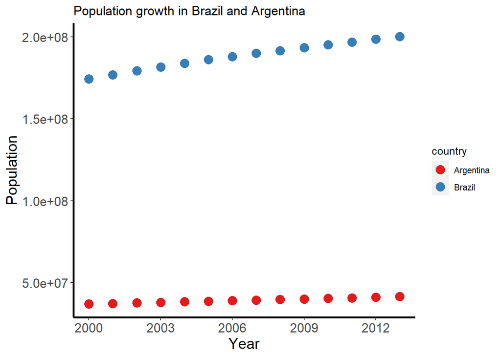

```r
# Filtering a sample dataset 'population'
population2 <- population %>%
    filter(country == "Brazil" | country == "Argentina", year >=
        2000)
# population2

# Simple dotplot
ggplot(population2, aes(x = year, y = population, color = country)) +
    geom_point(size = 4) + scale_x_continuous(breaks = (seq(min(population2$year),
    max(population2$year), by = 3))) + theme(panel.grid.major = element_blank(),
    panel.grid.minor = element_blank(), axis.text = element_text(size = 13),
    axis.title = element_text(size = 15), panel.background = element_blank(),
    axis.line = element_line(size = 1)) + scale_color_brewer(palette = "Set1") +
    labs(title = "Population growth in Brazil and Argentina",
        x = "Year", y = "Population")
```

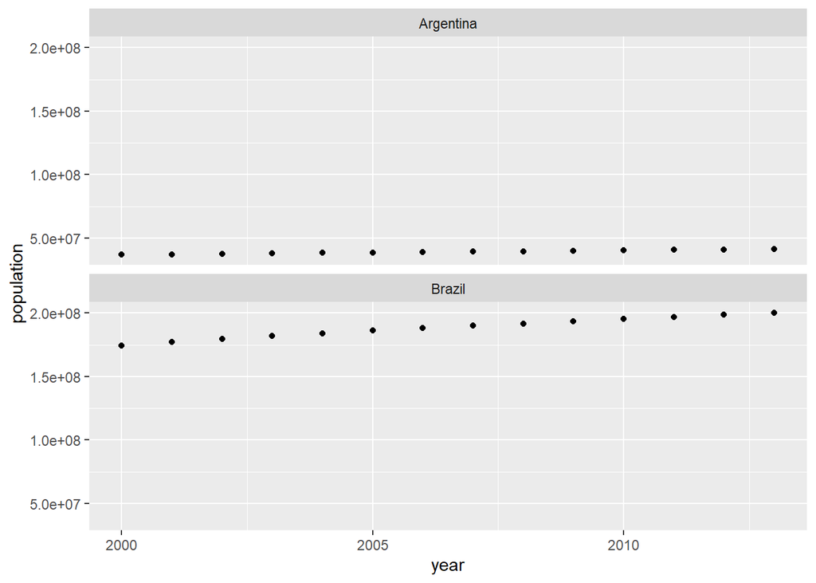

```r
# Faceted dotplot
ggplot(population2, aes(x = year, y = population)) + geom_point() +
    facet_wrap(~country, nrow = 2)
```

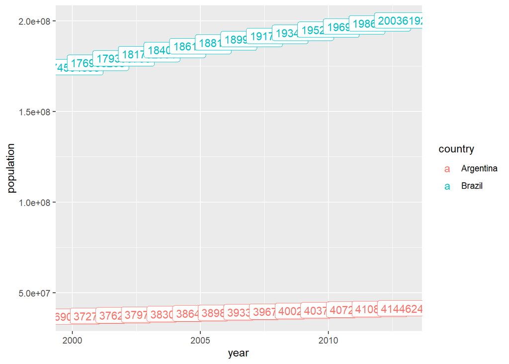

```r
# Dotplot with callouts
ggplot(population2, aes(x = year, y = population, color = country,
    label = population)) + geom_text(check_overlap = TRUE) +
    geom_label()
```

## 2.2 Scatterplots

```r
msleep
```

```
## # A tibble: 83 x 11
##    name   genus vore  order conservation sleep_total sleep_rem sleep_cycle awake
##    <chr>  <chr> <chr> <chr> <chr>              <dbl>     <dbl>       <dbl> <dbl>
##  1 Cheet~ Acin~ carni Carn~ lc                  12.1      NA        NA      11.9
##  2 Owl m~ Aotus omni  Prim~ <NA>                17         1.8      NA       7
##  3 Mount~ Aplo~ herbi Rode~ nt                  14.4       2.4      NA       9.6
##  4 Great~ Blar~ omni  Sori~ lc                  14.9       2.3       0.133   9.1
##  5 Cow    Bos   herbi Arti~ domesticated         4         0.7       0.667  20
##  6 Three~ Brad~ herbi Pilo~ <NA>                14.4       2.2       0.767   9.6
##  7 North~ Call~ carni Carn~ vu                   8.7       1.4       0.383  15.3
##  8 Vespe~ Calo~ <NA>  Rode~ <NA>                 7        NA        NA      17
##  9 Dog    Canis carni Carn~ domesticated        10.1       2.9       0.333  13.9
## 10 Roe d~ Capr~ herbi Arti~ lc                   3        NA        NA      21
## # ... with 73 more rows, and 2 more variables: brainwt <dbl>, bodywt <dbl>
```

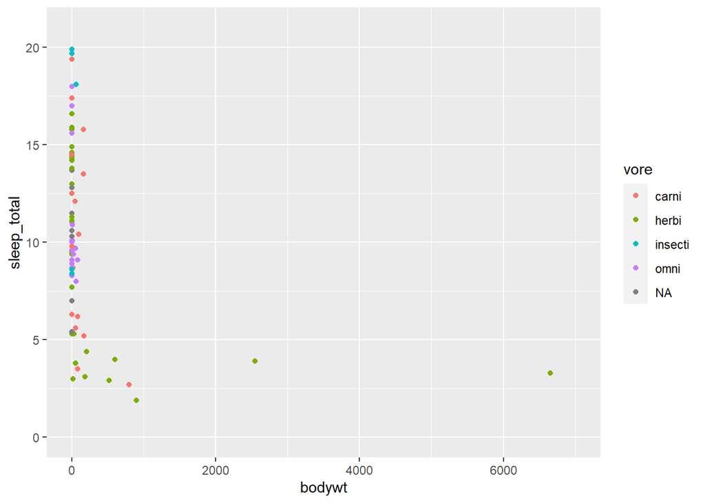

```r
# Scatterplot with df msleep
ggplot(msleep, aes(x = bodywt, y = sleep_total, colour = vore)) +
    geom_point() + xlim(0, 7000) + ylim(0, 21)
```

## 2.3 Histograms

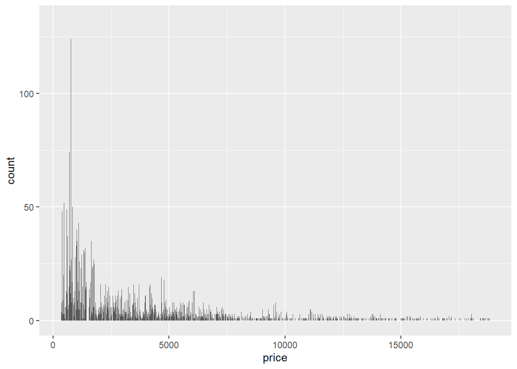

```r
ggplot(diamonds, aes(x = price)) + geom_bar()
```

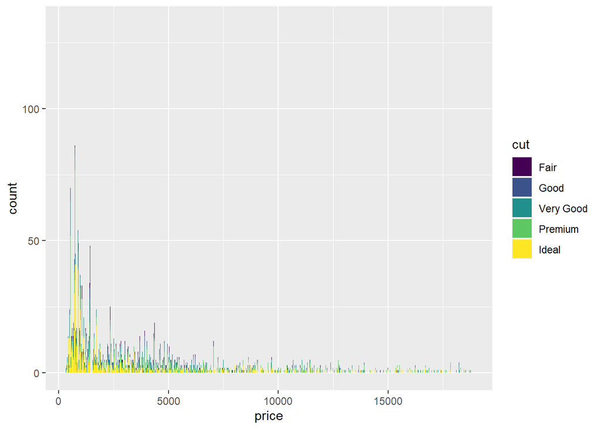

```r
ggplot(diamonds, aes(x = price, fill = cut)) + geom_bar()
```

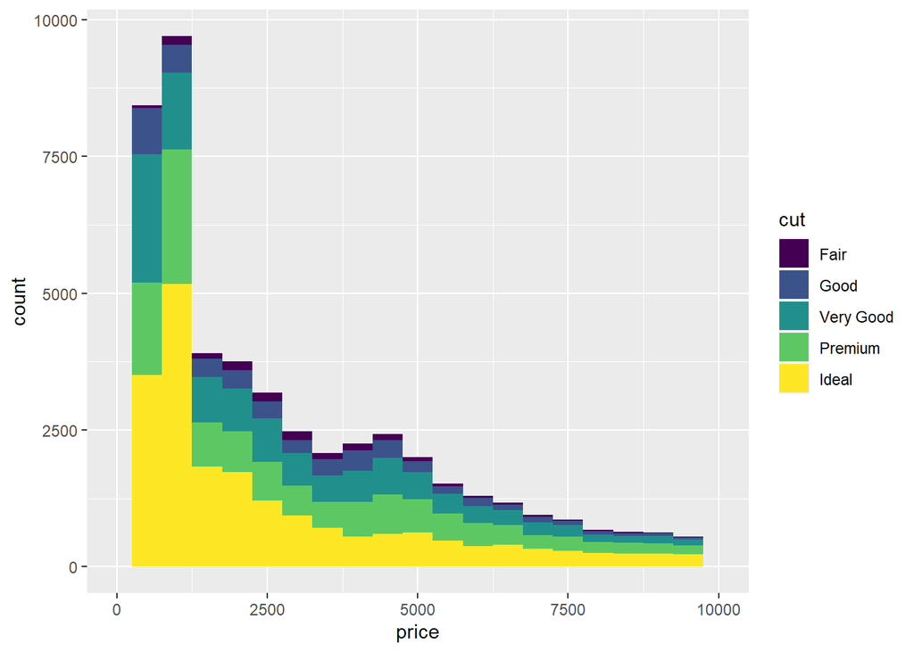

```r
ggplot(diamonds, aes(x = price, fill = cut)) + geom_histogram(binwidth = 500) +
    xlim(0, 10000)
```